# DDP W4 - Shiny

07/11/2020

## Introduction

This presentation is part of the Developing Data Products Coursera.org course project submission.

It is an R Presentation generated with RStudio.

## Application Overview

- The application is written in Shiny using R.
- The source code consists of two files: server.R and ui.R
- server.R consists of the code for the server of Shiny web application
- ui.R consists of the code for the user-interface definition, it uses the “sidebarLayout” template
- The application is hosted on Rstudio’s shiny server in the cloud (Shinyapps.io)

## Working

There are two main tabs:

- Plot: This displays the plot for the given dataframe
- Table: This displays an interactive table for the given dataframe

## Plot

[figure not shown]

## Table

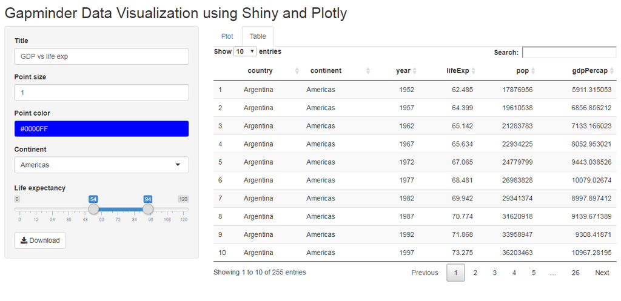